# Dog Breed Classifier

## Project

I always wanted to build a model that could be used by anyone. *'Tell me what type of dog it is'* is a simple idea that could be made into an app. It would tell you the type of dog on a picture or... the one that you resemble. The main problem is to build a classifier strong enough to work not only with clean and prepared data, but with more diverse one like user made photos.

Here I'm going to build a model for it. I will use a convolutional neural network (CNN), a network type doing really well with image recognition. First, I'm going to use pre-trained models to know if it is an image of a dog or a human. Then I will use a CNN to predict the matching breed. You will see me building two CNNs, one from scratch and the other one using transfer learning. I'm curious how they will compare.

## Imports

```python
import numpy as np

import matplotlib.pyplot as plt
%matplotlib inline
```

## Load data

The data are images of famous people and different types of dogs.

```python
from glob import glob

# Load filenames for human and dog images
human_files = np.array(glob('./data/lfw/*/*'))
dog_files = np.array(glob('./data/dog_images/*/*/*'))

# Print number of images in each dataset
print('There are %d total human images.' % len(human_files))
print('There are %d total dog images.' % len(dog_files))
```

```
There are 13233 total human images.
There are 8351 total dog images.
```

## Identify humans

As a first step I want the application to know whether it is dealing with a dog or a human image. I'm going to use a pre-trained face classifier, namely [Haar Cascades](https://docs.opencv.org/trunk/d7/d8b/tutorial_py_face_detection.html) from OpenCV. It has a a number of detectors that you can use with it. I've download one of them from [gihub](https://github.com/opencv/opencv/tree/master/data/haarcascades). It is stored as an XML file.

Let's apply it to an image and see how it works.

```
Number of faces detected: 1
```

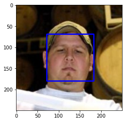

```python
import cv2

# Extract pre-trained face detector
face_cascade = cv2.CascadeClassifier('./haar_cascade/haarcascade_frontalface_alt.xml')

# Load color (BGR) image
img = cv2.imread(human_files[0])
# Convert BGR image to grayscale
gray = cv2.cvtColor(img, cv2.COLOR_BGR2GRAY)

# Find faces in image using face_cascade model
faces = face_cascade.detectMultiScale(gray)

# Print number of faces detected in the image
print('Number of faces detected:', len(faces))

# Get bounding box for each detected face
for (x,y,w,h) in faces:
    # add bounding box to color image
    cv2.rectangle(img,(x,y),(x+w,y+h),(255,0,0),2)

# Convert BGR image to RGB for plotting
cv_rgb = cv2.cvtColor(img, cv2.COLOR_BGR2RGB)

# Display the image, along with bounding box
plt.imshow(cv_rgb)
plt.show()
```

I start with converting an image to grayscale so the classifier can work with it. Then I obtain the result and keep it in `faces`. It is a 1D array with 4 elements, `x`, `y`, `w` and `h`. Basically what the algorithm does is it finds a rectangle with a face. It's left corner is given by `x`, `y` and its size is given by `w` and `h`.

### Human face detector

Here is a simple function to tell whether there is a human on a pic.

```python
# Returns "True" if face is detected in image stored at img_path
def face_detector(img_path):
    img = cv2.imread(img_path)
    gray = cv2.cvtColor(img, cv2.COLOR_BGR2GRAY)
    faces = face_cascade.detectMultiScale(gray)
    return len(faces) > 0
```

### Test it

Let's test this classifier on a hundred dog and human images. Ideally, you would expect it to score 0% on dogs and 100% on people.

```python
from tqdm import tqdm

human_files_short = human_files[:100]
dog_files_short = dog_files[:100]

# Returns the ratio of human faces detected on the image list
def human_face_ratio(img_path_list):
    detection = [face_detector(img_path) for img_path in tqdm(img_path_list, desc = 'Detecting human faces')]
    return sum(detection) / len(detection)

# Test the performance of the face_detector algorithm
print('Ratio of human faces detected in human images:', human_face_ratio(human_files_short))
print('Ratio of human faces detected in dog images:', human_face_ratio(dog_files_short))
```

```
Ratio of human faces detected in human images: 0.99
```

```
Ratio of human faces detected in dog images: 0.16
```

The results seem very acceptable. It looks like the algorithm is almost always right with images of people. When it comes to dog pictures, it recognizes a face quite rarely at only 16% of them.

## Identify dogs

I also want the network to know if there is a dog on the picture. For this task I'm going to use the VGG-16 model along with pre-trained weights. It was trained for general image recognition on a very large dataset, ImageNet.

I'm going to load it now.

```python
import torch
import torchvision.models as models

# Load VGG16 model
VGG16 = models.vgg16(pretrained=True)

# Check if CUDA is available
use_cuda = torch.cuda.is_available()

# Move model to GPU if CUDA is available
if use_cuda:
    VGG16 = VGG16.cuda()
```

### Prediction with VGG-16

If you provide VGG-16 model with an image, it will predict 1 out of 1000 categories for the object in the image.

I'm going to write a function that takes a path to an image file and returns the predicted class (index from 0 to 999).

```python
from PIL import Image
import torchvision.transforms as transforms

# Standard normalization values
# pre-trained models need normalization with these parameters
standard_normalization = transforms.Normalize(mean = [0.485, 0.456, 0.406],
                                              std = [0.229, 0.224, 0.225])

def VGG16_predict(img_path):
    '''
    Use pre-trained VGG-16 model to obtain index corresponding to
    predicted ImageNet class for image at specified path

    Args:
        img_path: path to an image

    Returns:
        Index corresponding to VGG-16 model's prediction
    '''

    ## Load an image from the given img_path
    image = Image.open(img_path).convert('RGB') # pre-trained models expect 3-channels = RGB

    # Pre-process it
    data_transform = transforms.Compose([
        # VGG-16 takes 224x224 images as input, so resize all of them
        transforms.RandomResizedCrop(224),
        transforms.ToTensor(),
        standard_normalization
    ])
    image = data_transform(image)
    image = image.unsqueeze(0) # add batch dimension (3, 224, 244) -> (1, 3, 224, 224)

    # Using the network only for inference so there is no need to track gradients
    torch.no_grad()

    # Move to GPU
    if use_cuda:
        image = image.cuda()

    ## Predict class probabilities for an image
    output = VGG16(image)
    # Convert output probabilities to predicted class (index)
    _, predicted_class = torch.max(output, 1)
    # Get a number from the 1x1 tensor
    predicted_class = predicted_class.data.tolist()[0]

    return predicted_class
```

### Dog detector

If you look at the [dictionary](https://gist.github.com/yrevar/942d3a0ac09ec9e5eb3a), you'll notice that the categories corresponding to dogs are in a range between 151 and 268. I'm going to write a function that will just return `True` or `False` depending if there is a dog on the picture.

```python
### Returns "True" if a dog is detected in the image from img_path
def dog_detector(img_path):
    predicted_class = VGG16_predict(img_path)
    is_dog = predicted_class >= 151 and predicted_class <= 268
    return is_dog
```

### Test it

Let's see how the dog detector performs and test its performance on human and dog images.

```python
human_files_short = human_files[:100]
dog_files_short = dog_files[:100]

# Returns the ratio of dogs detected on the image list
def dog_ratio(img_path_list):
    detection = [dog_detector(img_path) for img_path
                 # postition, leave are to avoid printing each additional 1% in a new line
                 in tqdm(img_path_list, desc = 'Detecting dogs', position = 0, leave = True)]
    return sum(detection) / len(detection)

## Test the performance of the face_detector algorithm on the images in human_files_short and dog_files_short
print('Ratio of dogs detected in human images:', dog_ratio(human_files_short))
print('Ratio of dogs detected in dog images:', dog_ratio(dog_files_short))
```

```
Ratio of dogs detected in human images: 0.0
```

```
Ratio of dogs detected in dog images: 0.95
```

It looks like a pretty solid performance. Vast majority of images were classfied correctly.

## CNN classifier (from scratch)

Now that I wrote the functions to detect dogs and humans in the images, it is the time to predict the actual dog breeds. My first attempt is to write a neural network from scratch.

Predicting dog breeds is a challenging task, so I don't expect the training accuracy to be high - especially that I am writing it from the start.

[output not shown]

Some breeds look very similar.

[output not shown]

Other types like labrador can be either yellow, chocolate or black. As you can imagine, it will be extra hard for the neural network to learn such relations.

[output not shown]

I won't need a high accuracy to beat the random chance model. When you always guess the same type, you have only 1% chance of being right (exactly it is a bit lower, equal to 1 out of 133 possible dog breeds). So any model with accuracy above 1% will be an improvement over random guessing.

### Data loaders for dog images

I'm going to prepare three dataloaders that will provide batches of images for training, validation and testing.

```python
import os
from torchvision import datasets
from torch.utils.data import DataLoader

batch_size = 128

# Define data directories
data_dir = './data/dog_images/'
train_dir = os.path.join(data_dir, 'train/')
valid_dir = os.path.join(data_dir, 'valid/')
test_dir = os.path.join(data_dir, 'test/')

# Define transforms for the training data with augumentation
train_transforms = transforms.Compose([transforms.RandomRotation(30),
                                       transforms.RandomResizedCrop(224),
                                       transforms.RandomHorizontalFlip(),
                                       transforms.ToTensor(),
                                       standard_normalization])

# Define transforms for the testing data (basic)
test_transforms = transforms.Compose([transforms.Resize((255, 255)),
                                      transforms.CenterCrop(224),
                                      transforms.ToTensor(),
                                      standard_normalization])

# Read and transform data using ImageFolder
train_data = datasets.ImageFolder(train_dir, transform = train_transforms)
valid_data = datasets.ImageFolder(valid_dir, transform = test_transforms)
test_data = datasets.ImageFolder(test_dir, transform = test_transforms)

# Define data loaders
train_loader = DataLoader(train_data, shuffle = True, batch_size = batch_size)
valid_loader = DataLoader(valid_data, shuffle = False, batch_size = batch_size)
test_loader = DataLoader(test_data, shuffle = False, batch_size = batch_size)

# Store loaders in a dictionary for future use
loaders_scratch = { 'train' : train_loader, 'valid' : valid_loader, 'test' : test_loader }

# Print out some data stats
print('Number of training images: ', len(train_data))
print('Number of validation images: ', len(valid_data))
print('Number of test images: ', len(test_data))

# Print the input tensor shape
data_iter = iter(train_loader)
image, label = data_iter.next()
print()
print('Input tensor shape:\n', image.shape)
print('Label shape:\n', label.shape)
```

```
Number of training images:  6680
Number of validation images:  835
Number of test images:  836

Input tensor shape:
 torch.Size([128, 3, 224, 224])
Label shape:
 torch.Size([128])
```

Whether you want to train the neural network or use it for prediction, it will always work with an image of the same size. That's why I am resizing all images to one size. I decided to go for 224 x 224 because it is a standard dimension. I could have chosen larger size which should give a little better accuracy but require more time to train.

I wanted to provide some randomness in the training data. How is it happening exactly? So first I take a crop of a random size and then resize it to the target resolution. Network won't memorize testing data so you don't need to bring in randomness to it. The process is simpler as I only bring the picture to a nearby size of 255 and then take a crop from the center to resize it to 224.

I decided to apply data agumentation to the training data. Thanks to this the network should generalize better. Apart from random crop, I randomly rotate an image between 0 to 30 degrees and either flip the image horizontally or not.

Finally, the input tensor is of size 128 x 3 x 224 x 224. Starting from the end, the image size is 224 x 224. 3 is the number of color filters (RGB). And the first one stands for batch size - images come in batches of 128 each. I decided to go for this batch size rather than e.g. 64 to shorten the training time at the cost of higher memory usage. Labels are just indexes from 1 to 133 standing for each of 133 dog breeds. There are 128 labels for each observation in the batch.

### Network architecture

Now I'm going to create a CNN model.

```python
import torch.nn as nn
import torch.nn.functional as F

# Define the CNN architecture
class Net(nn.Module):

    def __init__(self):
        super(Net, self).__init__()
        ## Define layers of a CNN
        # Convolutional & batch normalization layers
        self.conv1 = nn.Conv2d(in_channels = 3, out_channels = 16, kernel_size = 3, padding = 1)
        self.bn1 = nn.BatchNorm2d(16)
        self.conv2 = nn.Conv2d(in_channels = 16, out_channels = 32, kernel_size = 3, padding = 1)
        self.bn2 = nn.BatchNorm2d(32)
        self.conv3 = nn.Conv2d(in_channels = 32, out_channels = 64, kernel_size = 3, padding = 1)
        self.bn3 = nn.BatchNorm2d(64)
        self.conv4 = nn.Conv2d(in_channels = 64, out_channels = 128, kernel_size = 3, padding = 1)
        self.bn4 = nn.BatchNorm2d(128)
        self.conv5 = nn.Conv2d(in_channels = 128, out_channels = 256, kernel_size = 3, padding = 1)
        self.bn5 = nn.BatchNorm2d(256)
        self.conv6 = nn.Conv2d(in_channels = 256, out_channels = 512, kernel_size = 3, padding = 1, stride = 2)
        self.bn6 = nn.BatchNorm2d(512)
        # Pooling layers
        self.pool = nn.MaxPool2d(2, 2)
        # Output layer
        self.fc1 = nn.Linear(8192, 1024)
        self.fc2 = nn.Linear(1024, 133)
        # Dropout layer
        self.dropout = nn.Dropout(0.25)

    def forward(self, x):
        ## Define forward behavior
        # (224 x 224 x 3) -> (112 x 112 x 16)
        x = self.bn1(self.pool(self.conv1(x)))
        # (112 x 112 x 16) -> (56 x 56 x 32)
        x = self.bn2(self.pool(self.conv2(x)))
        # (56 x 56 x 32) -> (28 x 28 x 64)
        x = self.bn3(self.pool(self.conv3(x)))
        # (28 x 28 x 64) -> (14 x 14 x 128)
        x = self.bn4(self.pool(self.conv4(x)))
        # (14 x 14 x 128) -> (7 x 7 x 256)
        x = self.bn5(self.pool(self.conv5(x)))
        # (7 x 7 x 256) -> (4 x 4 x 512)
        x = self.bn6(self.conv6(x))
        # Flatten the result into a vector so it can be put into fc layer
        x = x.view(-1, 4 * 4 * 512)
        # Output layer
        x = self.dropout(F.relu(self.fc1(x)))
        x = self.fc2(x)
        return x

# Init the network
model_scratch = Net()

# Move tensors to GPU if CUDA is available
if use_cuda:
    model_scratch.cuda()
```

Before deciding on the architecture, I did a google search and viewed a few approaches to a similar problem. I took inspiration from this [approach](https://machinelearningmastery.com/how-to-develop-a-convolutional-neural-network-to-classify-photos-of-dogs-and-cats/).

I experimented with architecture for a while and found that adding convolutional layers improved the results. As you know, the classification task is going to be pretty hard. This is the reason I tried up to 6 convolutional layers. At this depth the model performed better than smaller variants but it also became quite heavy so I stopped increasing the number further.

The size of the convolutional layers' output was also important. For the last one, neither the size of 7 x 7 x 512 nor 1 x 1 x 512 were good. I found that the middle choice of 4 x 4 x 512 worked better. If it was too big, it required too many dense nodes which resulted in memory problems and a large model size. If it was too small, it gave not enough information for learning. This variant gave the lowest loss.

I decided to use dropout between linear layers to prevent overfitting. The parameters for all layers are pretty standard. I've also found that using batch normalization after each convolution & pooling block accelerated the learning process.

### Loss function and optimizer

I chose cross-entropy as the loss and gradient descent with momentum as the optimizer.

```python
import torch.optim as optim

# Specify loss function
criterion_scratch = nn.CrossEntropyLoss()

# Specify optimizer
optimizer_scratch = optim.SGD(model_scratch.parameters(), lr = 0.005, momentum = 0.9)
```

After trial and error I decided to stay at 0.005 learning rate which gave good results. Using momentum with the standard value 0.9 accelerated training.

### Train the model

Here is the training function. After each iteration it will save the model if the validation loss has decreased. This way I will keep the best model even if the loss starts increasing due to overfitting.

```python
from PIL import ImageFile
ImageFile.LOAD_TRUNCATED_IMAGES = True

def train(n_epochs, loaders, model, optimizer, criterion, use_cuda, save_path):
    """returns trained model"""
    # Initialize tracker for minimum validation loss
    valid_loss_min = np.Inf

    for epoch in range(1, n_epochs+1):
        # Initialize variables to monitor training and validation loss
        train_loss = 0.0
        valid_loss = 0.0

        ## Train the model
        model.train()
        for batch_idx, (data, target) in enumerate(loaders['train']):
            # Move to GPU
            if use_cuda:
                data, target = data.cuda(), target.cuda()
            # Clear the gradients
            optimizer.zero_grad()
            # Forward pass
            output = model(data)
            # Calculate the batch loss
            loss = criterion(output, target)
            # Backward pass
            loss.backward()
            # Parameter update
            optimizer.step()
            # Update training loss
            train_loss += loss.item() * data.size(0)

        ## Validate the model
        model.eval()
        for batch_idx, (data, target) in enumerate(loaders['valid']):
            # Move to GPU
            if use_cuda:
                data, target = data.cuda(), target.cuda()
            # Forward pass
            output = model(data)
            # Calculate the batch loss
            loss = criterion(output, target)
            # Update average validation loss
            valid_loss += loss.item() * data.size(0)

        # Print training/validation statistics
        print('Epoch: {} \tTraining Loss: {:.6f} \tValidation Loss: {:.6f}'.format(
            epoch,
            train_loss,
            valid_loss)
        )

        # Save model if validation loss has decreased
        if valid_loss <= valid_loss_min:
            print('Validation loss decreased ({:.6f} --> {:.6f}).  Saving model ...'.format(
                valid_loss_min,
                valid_loss)
            )
            torch.save(model.state_dict(), save_path)
            valid_loss_min = valid_loss

    # Return trained model
    return model
```

Let's train the model. I am going to run the algorithm for 50 iterations.

```python
num_epochs = 50

# Train the model
model_scratch = train(num_epochs, loaders_scratch, model_scratch, optimizer_scratch,
                      criterion_scratch, use_cuda, 'model_scratch.pt')
```

```
Epoch: 1 	Training Loss: 4.804576 	Validation Loss: 4.618811
Validation loss decreased (inf --> 4.618811).  Saving model ...
Epoch: 2 	Training Loss: 4.606536 	Validation Loss: 4.456580
Validation loss decreased (4.618811 --> 4.456580).  Saving model ...
Epoch: 3 	Training Loss: 4.489757 	Validation Loss: 4.308447
Validation loss decreased (4.456580 --> 4.308447).  Saving model ...
Epoch: 4 	Training Loss: 4.409342 	Validation Loss: 4.238378
Validation loss decreased (4.308447 --> 4.238378).  Saving model ...
Epoch: 5 	Training Loss: 4.359481 	Validation Loss: 4.209231
Validation loss decreased (4.238378 --> 4.209231).  Saving model ...
Epoch: 6 	Training Loss: 4.294341 	Validation Loss: 4.107318
Validation loss decreased (4.209231 --> 4.107318).  Saving model ...
Epoch: 7 	Training Loss: 4.243336 	Validation Loss: 4.090380
Validation loss decreased (4.107318 --> 4.090380).  Saving model ...
Epoch: 8 	Training Loss: 4.186671 	Validation Loss: 4.036950
Validation loss decreased (4.090380 --> 4.036950).  Saving model ...
Epoch: 9 	Training Loss: 4.164761 	Validation Loss: 3.977424
Validation loss decreased (4.036950 --> 3.977424).  Saving model ...
Epoch: 10 	Training Loss: 4.109555 	Validation Loss: 3.974312
Validation loss decreased (3.977424 --> 3.974312).  Saving model ...
Epoch: 11 	Training Loss: 4.066892 	Validation Loss: 3.916565
Validation loss decreased (3.974312 --> 3.916565).  Saving model ...
Epoch: 12 	Training Loss: 4.012462 	Validation Loss: 3.907179
Validation loss decreased (3.916565 --> 3.907179).  Saving model ...
Epoch: 13 	Training Loss: 4.009318 	Validation Loss: 3.865983
Validation loss decreased (3.907179 --> 3.865983).  Saving model ...
Epoch: 14 	Training Loss: 3.966360 	Validation Loss: 4.112934
Epoch: 15 	Training Loss: 3.915899 	Validation Loss: 3.820977
Validation loss decreased (3.865983 --> 3.820977).  Saving model ...
Epoch: 16 	Training Loss: 3.904706 	Validation Loss: 3.767679
Validation loss decreased (3.820977 --> 3.767679).  Saving model ...
Epoch: 17 	Training Loss: 3.911075 	Validation Loss: 3.782880
Epoch: 18 	Training Loss: 3.843491 	Validation Loss: 3.720971
Validation loss decreased (3.767679 --> 3.720971).  Saving model ...
Epoch: 19 	Training Loss: 3.814659 	Validation Loss: 3.702405
Validation loss decreased (3.720971 --> 3.702405).  Saving model ...
Epoch: 20 	Training Loss: 3.795071 	Validation Loss: 3.700074
Validation loss decreased (3.702405 --> 3.700074).  Saving model ...
Epoch: 21 	Training Loss: 3.772924 	Validation Loss: 3.674187
Validation loss decreased (3.700074 --> 3.674187).  Saving model ...
```

[output cut: 26 more lines]

```
Epoch: 41 	Training Loss: 3.239835 	Validation Loss: 3.302684
Epoch: 42 	Training Loss: 3.196468 	Validation Loss: 3.293506
Epoch: 43 	Training Loss: 3.206120 	Validation Loss: 3.240559
Validation loss decreased (3.241147 --> 3.240559).  Saving model ...
Epoch: 44 	Training Loss: 3.170317 	Validation Loss: 3.218317
Validation loss decreased (3.240559 --> 3.218317).  Saving model ...
Epoch: 45 	Training Loss: 3.167513 	Validation Loss: 3.277675
Epoch: 46 	Training Loss: 3.165712 	Validation Loss: 3.214165
Validation loss decreased (3.218317 --> 3.214165).  Saving model ...
Epoch: 47 	Training Loss: 3.136869 	Validation Loss: 3.171707
Validation loss decreased (3.214165 --> 3.171707).  Saving model ...
Epoch: 48 	Training Loss: 3.081371 	Validation Loss: 3.131985
Validation loss decreased (3.171707 --> 3.131985).  Saving model ...
Epoch: 49 	Training Loss: 3.101227 	Validation Loss: 3.154693
Epoch: 50 	Training Loss: 3.052216 	Validation Loss: 3.171585
```

After trying the architecture with one convolutional layer less I observed that the validation loss curve was bouncing up and dwon around the training loss level. Bringing the additional 6th layer stabilized the curve compared to the smaller model.

### Load the model

I'm going to load the best trained model that as you can remember was automatically saved at the lowest validation loss.

```python
model_scratch = Net()

if use_cuda:
    model_scratch.cuda()

if use_cuda:
    map_location = lambda storage, loc: storage.cuda()
else:
    map_location = 'cpu'

model_scratch.load_state_dict(torch.load('model_scratch.pt', map_location = map_location))
```

```
<All keys matched successfully>
```

### Test the model

It's time for evaluation on test data.

```python
def test(loaders, model, criterion, use_cuda):

    # Monitor test loss and accuracy
    test_loss = 0.
    correct = 0.
    total = 0.

    model.eval()

    with torch.no_grad():
        for batch_idx, (data, target) in enumerate(loaders['test']):
            # Move to GPU
            if use_cuda:
                data, target = data.cuda(), target.cuda()
            # Forward pass: compute predicted outputs by passing inputs to the model
            output = model(data)
            # Calculate the loss
            loss = criterion(output, target)
            # Update average test loss
            test_loss = test_loss + ((1 / (batch_idx + 1)) * (loss.data - test_loss))
            # Convert output probabilities to predicted class
            pred = output.data.max(1, keepdim=True)[1]
            # Compare predictions to true label
            correct += np.sum(np.squeeze(pred.eq(target.data.view_as(pred))).cpu().numpy())
            total += data.size(0)

    model.train()

    print('Test Loss: {:.6f}\n'.format(test_loss))

    print('\nTest Accuracy: %2d%% (%2d/%2d)' % (
        100. * correct / total, correct, total))

# Call test function
test(loaders_scratch, model_scratch, criterion_scratch, use_cuda)
```

```
Test Loss: 3.103126


Test Accuracy: 25% (210/836)
```

The result doesn't seem great, but it took quite a few rounds of trial and error to get to this level while keeping the model modest.

## CNN classifier (transfer learning)

In this section I'm going to build a CNN using a pretrained model. I will use ResNet-50. It is a deep architecture with residual modules that help gradient to reach further during backpropagation. As the model was pre-trained for image classification, you can expect fairly good results by just adjusting the output layers.

Let's load it and look at its structure first.

```python
model_transfer = models.resnet50(pretrained = True)
model_transfer
```

```
ResNet(
  (conv1): Conv2d(3, 64, kernel_size=(7, 7), stride=(2, 2), padding=(3, 3), bias=False)
  (bn1): BatchNorm2d(64, eps=1e-05, momentum=0.1, affine=True, track_running_stats=True)
  (relu): ReLU(inplace=True)
  (maxpool): MaxPool2d(kernel_size=3, stride=2, padding=1, dilation=1, ceil_mode=False)
  (layer1): Sequential(
    (0): Bottleneck(
      (conv1): Conv2d(64, 64, kernel_size=(1, 1), stride=(1, 1), bias=False)
      (bn1): BatchNorm2d(64, eps=1e-05, momentum=0.1, affine=True, track_running_stats=True)
      (conv2): Conv2d(64, 64, kernel_size=(3, 3), stride=(1, 1), padding=(1, 1), bias=False)
      (bn2): BatchNorm2d(64, eps=1e-05, momentum=0.1, affine=True, track_running_stats=True)
      (conv3): Conv2d(64, 256, kernel_size=(1, 1), stride=(1, 1), bias=False)
      (bn3): BatchNorm2d(256, eps=1e-05, momentum=0.1, affine=True, track_running_stats=True)
      (relu): ReLU(inplace=True)
      (downsample): Sequential(
        (0): Conv2d(64, 256, kernel_size=(1, 1), stride=(1, 1), bias=False)
        (1): BatchNorm2d(256, eps=1e-05, momentum=0.1, affine=True, track_running_stats=True)
      )
    )
    (1): Bottleneck(
      (conv1): Conv2d(256, 64, kernel_size=(1, 1), stride=(1, 1), bias=False)
      (bn1): BatchNorm2d(64, eps=1e-05, momentum=0.1, affine=True, track_running_stats=True)
      (conv2): Conv2d(64, 64, kernel_size=(3, 3), stride=(1, 1), padding=(1, 1), bias=False)
      (bn2): BatchNorm2d(64, eps=1e-05, momentum=0.1, affine=True, track_running_stats=True)
      (conv3): Conv2d(64, 256, kernel_size=(1, 1), stride=(1, 1), bias=False)
      (bn3): BatchNorm2d(256, eps=1e-05, momentum=0.1, affine=True, track_running_stats=True)
      (relu): ReLU(inplace=True)
    )
    (2): Bottleneck(
      (conv1): Conv2d(256, 64, kernel_size=(1, 1), stride=(1, 1), bias=False)
      (bn1): BatchNorm2d(64, eps=1e-05, momentum=0.1, affine=True, track_running_stats=True)
      (conv2): Conv2d(64, 64, kernel_size=(3, 3), stride=(1, 1), padding=(1, 1), bias=False)
      (bn2): BatchNorm2d(64, eps=1e-05, momentum=0.1, affine=True, track_running_stats=True)
      (conv3): Conv2d(64, 256, kernel_size=(1, 1), stride=(1, 1), bias=False)
      (bn3): BatchNorm2d(256, eps=1e-05, momentum=0.1, affine=True, track_running_stats=True)
      (relu): ReLU(inplace=True)
    )
  )
  (layer2): Sequential(
    (0): Bottleneck(
```

[output cut: 121 more lines]

```
      (relu): ReLU(inplace=True)
    )
    (2): Bottleneck(
      (conv1): Conv2d(2048, 512, kernel_size=(1, 1), stride=(1, 1), bias=False)
      (bn1): BatchNorm2d(512, eps=1e-05, momentum=0.1, affine=True, track_running_stats=True)
      (conv2): Conv2d(512, 512, kernel_size=(3, 3), stride=(1, 1), padding=(1, 1), bias=False)
      (bn2): BatchNorm2d(512, eps=1e-05, momentum=0.1, affine=True, track_running_stats=True)
      (conv3): Conv2d(512, 2048, kernel_size=(1, 1), stride=(1, 1), bias=False)
      (bn3): BatchNorm2d(2048, eps=1e-05, momentum=0.1, affine=True, track_running_stats=True)
      (relu): ReLU(inplace=True)
    )
  )
  (avgpool): AdaptiveAvgPool2d(output_size=(1, 1))
  (fc): Linear(in_features=2048, out_features=1000, bias=True)
)
```

### Model architecture

It looks like it is enough to substitute `fc` layer at the end. I'm going to freeze the model's weights so only the new classfier part will be trained.

```python
# Freeze parameters
for param in model_transfer.parameters():
    param.requires_grad = False

# Add a new classifier part
classifier = nn.Sequential(nn.Linear(2048, 133, bias = True),
                           nn.LogSoftmax(dim = 1))
model_transfer.fc = classifier

# Use gpu if possible
if use_cuda:
    model_transfer = model_transfer.cuda()
```

### Loss and optimizer

This time I'm going to use a negative log-likelihood loss with an adaptive optimization algorithm. The algorithm will be set to optimize only the parameters of the last layer.

```python
criterion_transfer = nn.NLLLoss()
optimizer_transfer = optim.Adam(model_transfer.fc.parameters(), lr = 0.001)
```

### Train the model

I'm going to use the `train` function defined earlier. You can use loaders from previous model as the standard normalization parameters that I used meet the model's requirements.

```python
num_epochs = 10

# Train the model
model_transfer = train(num_epochs, loaders_scratch, model_transfer, optimizer_transfer,
                       criterion_transfer, use_cuda, 'model_transfer.pt')
```

```
Epoch: 1 	Training Loss: 3.273664 	Validation Loss: 1.431724
Validation loss decreased (inf --> 1.431724).  Saving model ...
Epoch: 2 	Training Loss: 1.563612 	Validation Loss: 0.853412
Validation loss decreased (1.431724 --> 0.853412).  Saving model ...
Epoch: 3 	Training Loss: 1.215725 	Validation Loss: 0.654998
Validation loss decreased (0.853412 --> 0.654998).  Saving model ...
Epoch: 4 	Training Loss: 1.057852 	Validation Loss: 0.571653
Validation loss decreased (0.654998 --> 0.571653).  Saving model ...
Epoch: 5 	Training Loss: 0.969005 	Validation Loss: 0.512643
Validation loss decreased (0.571653 --> 0.512643).  Saving model ...
Epoch: 6 	Training Loss: 0.863213 	Validation Loss: 0.498232
Validation loss decreased (0.512643 --> 0.498232).  Saving model ...
Epoch: 7 	Training Loss: 0.861288 	Validation Loss: 0.481663
Validation loss decreased (0.498232 --> 0.481663).  Saving model ...
Epoch: 8 	Training Loss: 0.837714 	Validation Loss: 0.480120
Validation loss decreased (0.481663 --> 0.480120).  Saving model ...
Epoch: 9 	Training Loss: 0.792531 	Validation Loss: 0.446741
Validation loss decreased (0.480120 --> 0.446741).  Saving model ...
Epoch: 10 	Training Loss: 0.734780 	Validation Loss: 0.467962
```

The model quickly reached the bottom loss of about 0.50 and it needed only 6 iterations to do so. From this point it improved only a little and it looks like the model converged.

### Test the model

Let's see its performance on the test data.

```python
if use_cuda:
    map_location = lambda storage, loc: storage.cuda()
else:
    map_location = 'cpu'

# Load the model that got the best validation accuracy
model_transfer.load_state_dict(torch.load('model_transfer.pt', map_location = map_location))

test(loaders_scratch, model_transfer, criterion_transfer, use_cuda)
```

```
Test Loss: 0.445302


Test Accuracy: 87% (730/836)
```

You can see that performance upgrade from transfer learning is massive. The model is doing well with 87% accuracy.

### Make a prediction

Now I'm going to write a function utilising the model. You can use it to predict a dog breed.

```python
# Move model back to the device
if use_cuda:
    model_transfer.to('cpu')

# Dictionary mapping labels (integers) to class names (dog breeds)
class_names = [item[4:].replace("_", " ") for item in test_data.classes]

# Load the image and return the predicted breed or a few best predictions
def predict_breed_transfer(img_path, n_predictions = 1):
    # Load the image and return the predicted breed
    image = Image.open(img_path)

    # Normalize and resize the image
    data_transform = transforms.Compose([
        # First bring it to a nearby size, then crop
        transforms.Resize(255),
        transforms.CenterCrop(224),
        transforms.ToTensor(),
        standard_normalization
    ])
    image_input = data_transform(image).unsqueeze(0)

    # Model's results
    top_n_class_names, top_n_probabilities, top_n_labels = \
        get_top_n_results(image_input, n_predictions)

    # For only one prediction, return scalars
    if n_predictions == 1:
        return top_n_class_names[0], top_n_probabilities[0], top_n_labels[0]
    # For a number of them, return ndarray
    else:
        return top_n_class_names, top_n_probabilities, top_n_labels

# Function that returns top n results of a model
def get_top_n_results(image_input, n ):
    # Get model predictions
    model_transfer.eval()
    with torch.no_grad():
        predictions = model_transfer(image_input).detach().numpy()
    model_transfer.train()
    # Predictions is an array in array, so get rid of the outer one
    predictions = predictions[0]

    # Sort predcitions' indexes (~ labels) in descending order
    sorted_indexes = np.argsort(predictions)[::-1]
    # Index will become a label after adding 1
    sorted_labels = np.add(sorted_indexes, 1).tolist()
    # Pick top n class names
    top_n_labels = sorted_labels[0 : n]
    # Class_names are indexed from 0 so I need to subtract 1
    top_n_class_names = [class_names[label-1] for label in top_n_labels]

    # Get top n probabilites
    softmax = lambda x : np.exp(x) / sum(np.exp(x))
    probabilities = softmax(predictions)
    sorted_probabilities = np.sort(probabilities)[::-1]
    top_n_probabilities = sorted_probabilities[0 : n].tolist()

    return top_n_class_names, top_n_probabilities, top_n_labels
```

And a test.

```python
predict_breed_transfer('images/American_water_spaniel_00648.jpg')
```

```
('Curly-coated retriever', 0.5246009826660156, 55)
```

It looks like the model is wrong. But how wrong is it? If you actually look up both breeds in google, you will find that they look very similar. Knowing this, you can see that the model works, although it's not perfectly accurate.

## App algorithm

Now that I have a classifier, I'm going to write an algorithm that could be part of the app. The idea is simple. After you pass an image file, you can expect one out of three possible answers. If it is an image of a dog, the app should tell you its breed. If it is an image of a human, it should tell you what type of dog he or she looks like. If the picture does not contain a dog or a human, the app should inform you about it.

Actually, I want to make the algorithm more useful. I am going to add an optional parameter `n_predictions`, so you can choose to get a number of top predictions for your image.

```python
import prediction_plots as plots

def run_app(img_path, n_predictions = 1):
    # Load image
    image = Image.open(img_path)

    # For dog or human start with a greeting
    if dog_detector(img_path):
        print("What a nice dog!")
    elif face_detector(img_path):
        print("Hello human!")
    # 'haven't found any' message
    else:
        plots.plot_no_prediction(image)
        # Info
        print("I have recognized neither dog nor human \n")
        # Stop
        return

    ## Continue depending on the number of predictions
    class_name, probability = None, None

    if n_predictions == 1:
        class_name, probability = single_prediction(img_path, image)
    else:
        class_name, probability = multiple_predictions(img_path,
                                                       image,
                                                       n_predictions)

    # Result
    if dog_detector(img_path):
        print("It is ...", class_name)
    elif face_detector(img_path):
        print("You look like ...", class_name)
    print('I am {:.2%} sure \n'.format(probability))

# Get single prediction results and plot them
def single_prediction(img_path, image):
    # Prediction
    class_name, probability, label = predict_breed_transfer(img_path)
    # Load predcited breed image
    predicted_img_path = find_predicted_breed_image_path(label)
    predicted_breed_image = plt.imread(predicted_img_path)

    plots.plot_single_prediction(image, predicted_breed_image)

    return class_name, probability

# Get multiple prediction results and plot them
def multiple_predictions(img_path, image, top_k = 5):
    # Prediction
    class_names, probabilities, labels = predict_breed_transfer(img_path, top_k)
    # Load predcited breed image
    predicted_img_path = find_predicted_breed_image_path(labels[0])
    predicted_breed_image = plt.imread(predicted_img_path)

    plots.plot_multiple_predictions(image,
                                     predicted_breed_image,
                                     class_names,
                                     probabilities)

    return class_names[0], probabilities[0]

# Function finding path to a first image of a given label (dog breed)
def find_predicted_breed_image_path(label):
    # Pad label with zeros
    padded_label = str(label).rjust(3, '0')
    # Path to directory of that label
    dir_path = os.path.join('./data/dog_images/train/', padded_label + '*')
    dir_path = glob(dir_path)[0]
    # File names in this directory
    file_names = os.listdir(dir_path)

    file_path = os.path.join(dir_path, file_names[0])
    return file_path
```

### Test

I want to see how this algorithm works. I'm going to try it out with a few images. Let's start with people photos.

```
Hello human!
```

[figure not shown]

```
You look like ... Australian shepherd
I am 9.52% sure

Hello human!
```

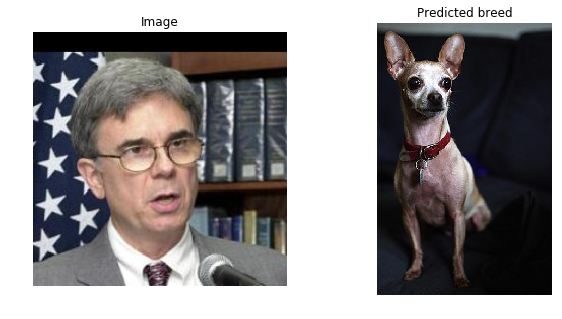

```
You look like ... Chihuahua
I am 7.95% sure

Hello human!
```

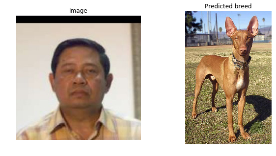

```
You look like ... Pharaoh hound
I am 17.92% sure
```

```python
# Set a seed for consistent results
np.random.seed(123)

# Human pictures
people_selection = np.random.choice(human_files, 3)

for img in people_selection:
    run_app(img)
```

Nice. As you can see, algorithm correctly identified people. You can even say that dog pictures are somewhat similar to the human pictures. Especially the angle in which head is rotated matches in both of the images.

Now I'm going to randomly select three dog pictures.

```python
np.random.seed(123)

dog_selection = np.random.choice(dog_files, 3)
dog_selection
```

```
array([ '/data/dog_images/train/065.Entlebucher_mountain_dog/Entlebucher_mountain_dog_04581.jpg',
       '/data/dog_images/train/007.American_foxhound/American_foxhound_00506.jpg',
       '/data/dog_images/train/090.Italian_greyhound/Italian_greyhound_06112.jpg'],
      dtype='<U106')
```

Let's see how the algorithm performs with dog pictures. At the end of each file path there is a name of the dog. It will make it easy to evaluate the results.

```
What a nice dog!
```

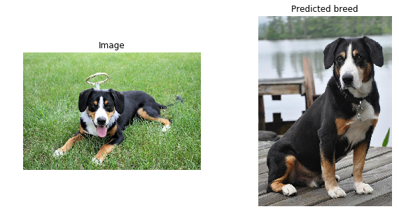

```
It is ... Entlebucher mountain dog
I am 97.37% sure

What a nice dog!
```

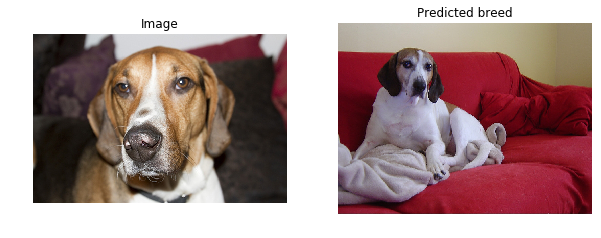

```
It is ... American foxhound
I am 80.80% sure

What a nice dog!
```

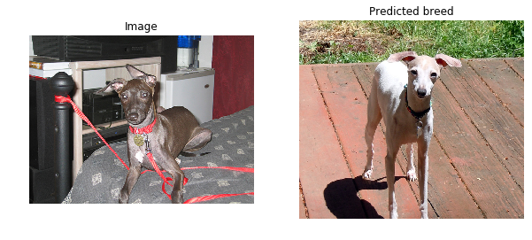

```
It is ... Italian greyhound
I am 99.41% sure
```

```python
for img in dog_selection:
    run_app(img)
```

The algorithm was correct each time. That's very good!

And another picture, this time of neither human nor dog.

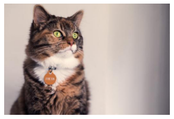

```
I have recognized neither dog nor human
```

```python
cat_img_path = 'images/Cat.jpg'

run_app(cat_img_path)
```

Correct again. Algorithm didn't let itself be fooled that cat is a dog.

The last test evaluates multiple predictions. The perfect example will be a picture of a mixed-breed dog.

```
What a nice dog!
```

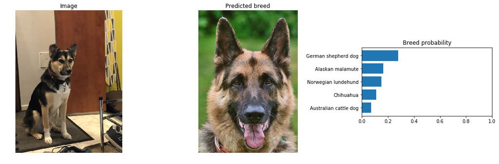

```
It is ... German shepherd dog
I am 27.95% sure
```

```python
rin_img_path = 'images/Rin.jpg'

run_app(rin_img_path, 5)
```

Predictions look really convincing. The dog indeed looks to be mostly of this breed. You can look up the second breed online. It is also very similar.

## Possible improvements

The model performs better than I expected. It is quite funny that you can find some kind of similarity between matched humans and dogs. I can think of at least a few ways in which its performance could be improved even futher.

Let's take a look at the distribution of images.

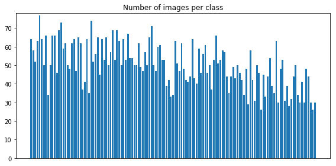

```python
# Count the number of images per class
image_count = np.zeros(133)

for _, y in train_data:
    image_count[y] += 1

# Plot it
fig, ax = plt.figure(figsize=(8, 4)), plt.subplot()
x_ticks = np.arange(len(image_count))
ax.bar(x_ticks, image_count)
ax.set_xticks([])
ax.set_title('Number of images per class')
ax.set_ylim(0, np.max(image_count) + 1)
plt.tight_layout()
plt.show()
```

From the plot you can see that classes are imbalanced. It can lead to a situation in which a neural network favors overrepresented class over the underrepresented one. In other words, it reduces the prediction accuracy. To combat this, you can use class weighting or oversampling.

There are also many ways in which the model from scratch could be improved. I could fine tune the model with kernel regularization and learning rate decay. You could also try deeper architecture, possibly using ResNet residual modules.

The accuracy of the transfer learning model could also be improved. The pre-trained model is powerful and it tends to overfit quickly. However, I could apply regularization and more sophisticated data augmentation to reduce this effect.